# Analyzing Individual BGG Users

Phil Henrickson

2022-01-02

# **ruroniken’s** BoardGameGeek Collection

This notebook contains a set of analyses for the selected user’s boardgamegeek collection. The bulk of the analysis is focused on building a user-specific predictive model to predict the games that ruroniken is likely to own. This enables to ask questions like, based on the games the user currently owns, what games are a good fit for their collection? What upcoming games are they likely to purchase?

This analysis is based on data from BoardGameGeek that was last updated on **2021-12-20.**

# 1 Collection Overview

We can look at a basic description of the number of games that the user owns, has rated, has previously owned, etc.

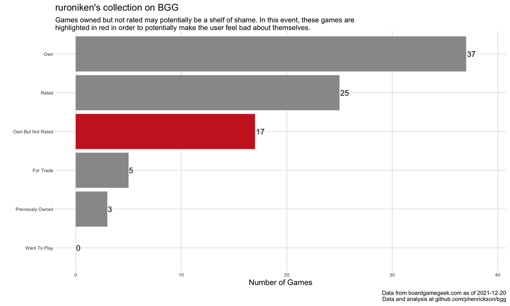

What years has the user owned/rated games from? While we can’t see when a user added or removed a game from their collection, we can look at their collection by the years in which their games were published.

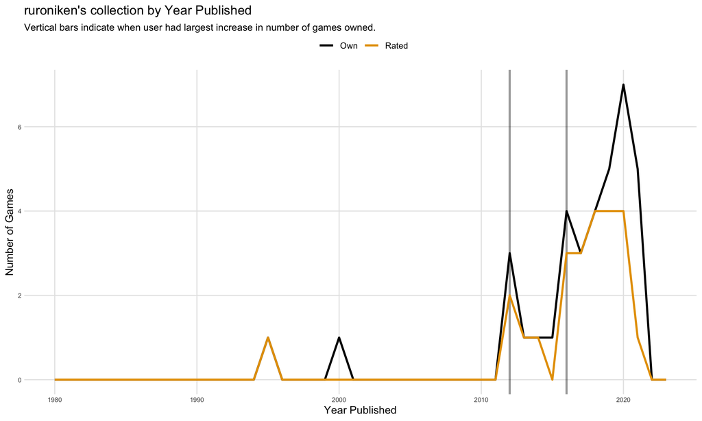

## 1.1 What types of games does ruroniken own?

We can look at the most frequent types of categories, mechanics, designers, and artists that appear in a user’s collection.

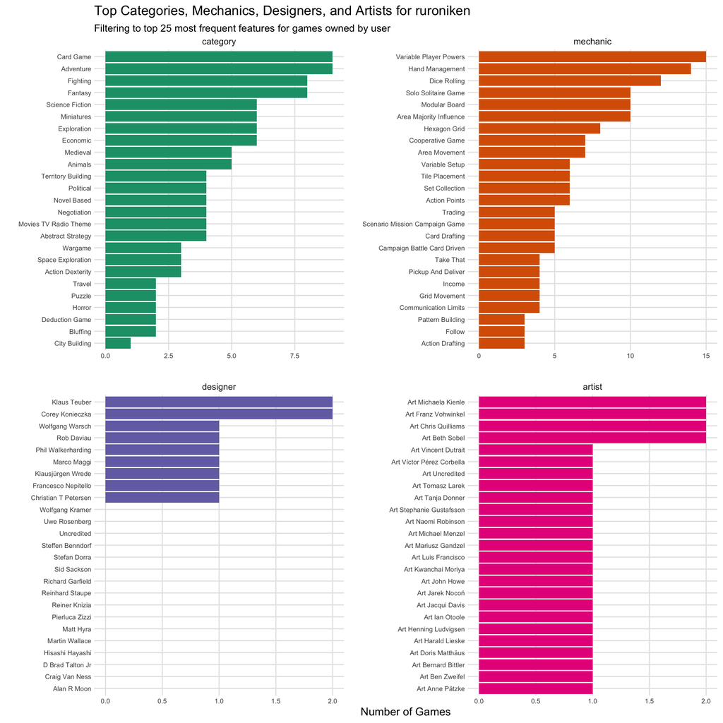

# 2 Modeling **ruroniken’s** Collection

| username | dataset | period | games_owned | games_rated | games_played |
| --- | --- | --- | --- | --- | --- |
| ruroniken | training | published before 2020 | 24 | 19 | 29 |
| ruroniken | test | published 2020 or later | 12 | 5 | 14 |

There are two main (binary) outcomes we will be modeling for the user.

The first, **own** refers to whether the user currently lists a game as owned in their collection. The second, **played** refers to whether the user currently owns, has rated, or previously owned a game. This means the latter will generally have a larger list of games, but may still be a useful category to examine for people who play lots of games without necessarily owning them.

We will train predictive models to learn the probability that the user will own or play individual games based on their features.

## 2.1 Coefficients for ruroniken

We can examine coefficients from the trained modes, which are penalized logistic regressions fit to our two main outcomes. Positive values indicate that a feature increases a user’s probabilility of owning/rating a game, while negative values indicate a feature decreases the probability.

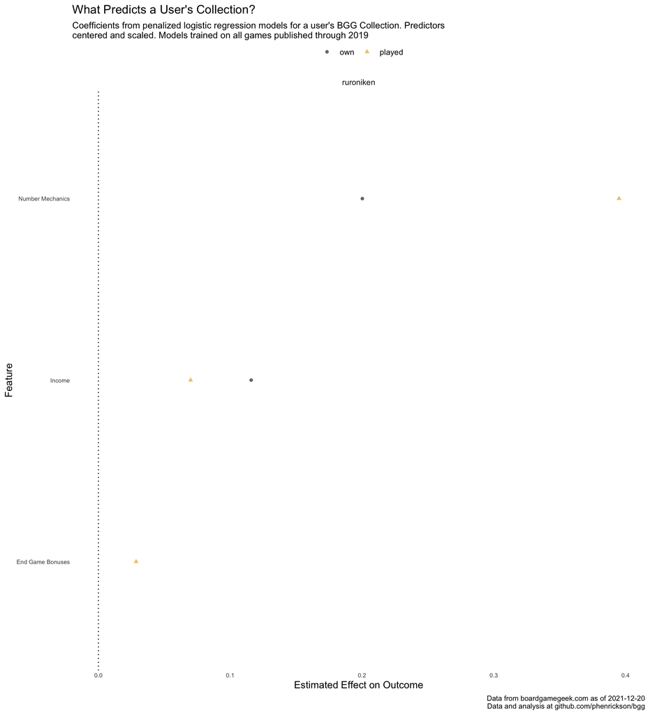

## 2.2 Visualizing Predictors for ruroniken’s Collection

Why did the model identify these features? We can make density plots of the important features for predicting whether the user owned a game. Blue indicates the density for games owned by the user, while grey indicates the density for games not owned by the user.

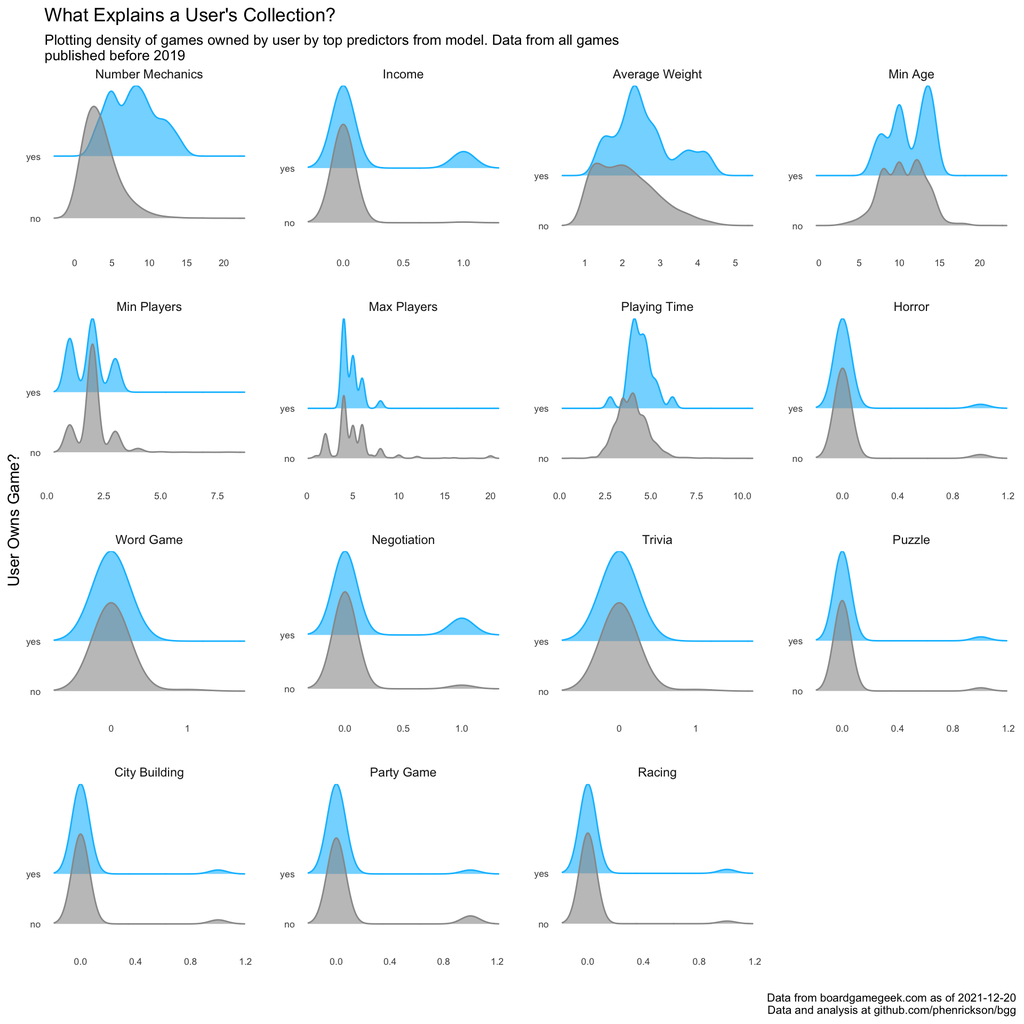

Binary predictors can be difficult to see with this visualization, so we can also directly examine the percentage of games in a user’s collection with a predictor vs the percentage of all games with that predictor.

| username | Feature | % of Games with Feature In_Collection | % of Games with Feature All_Games | Ratio |
| --- | --- | --- | --- | --- |
| ruroniken | Income | 16.7% | 0.7% | 24.2 |
| ruroniken | Negotiation | 16.7% | 3.6% | 4.6 |
| ruroniken | Miniatures | 16.7% | 5.3% | 3.1 |
| ruroniken | Fighting | 20.8% | 9.1% | 2.3 |
| ruroniken | Trains | 4.2% | 2.2% | 1.9 |
| ruroniken | Racing | 4.2% | 2.8% | 1.5 |
| ruroniken | Medieval | 8.3% | 6.3% | 1.3 |
| ruroniken | Deduction Game | 8.3% | 6.4% | 1.3 |
| ruroniken | Puzzle | 4.2% | 3.4% | 1.2 |
| ruroniken | Horror | 4.2% | 4.0% | 1.1 |
| ruroniken | City Building | 4.2% | 4.3% | 1.0 |
| ruroniken | Action Dexterity | 4.2% | 4.8% | 0.9 |
| ruroniken | Ancient | 4.2% | 4.5% | 0.9 |
| ruroniken | Party Game | 4.2% | 8.5% | 0.5 |
| ruroniken | Word Game | 0.0% | 1.8% | 0.0 |
| ruroniken | Trivia | 0.0% | 1.8% | 0.0 |
| ruroniken | Mafia | 0.0% | 0.7% | 0.0 |
| ruroniken | Prehistoric | 0.0% | 1.0% | 0.0 |
| ruroniken | Realtime | 0.0% | 4.2% | 0.0 |
| ruroniken | Sports | 0.0% | 2.0% | 0.0 |
| ruroniken | Murdermystery | 0.0% | 1.8% | 0.0 |
| ruroniken | Childrens Game | 0.0% | 5.7% | 0.0 |
| ruroniken | Memory Game | 0.0% | 1.7% | 0.0 |
| ruroniken | World War II | 0.0% | 4.0% | 0.0 |
| ruroniken | Napoleonic | 0.0% | 0.7% | 0.0 |

# 3 Assess Model’s Performance on Training Set

Before predicting games in upcoming years, we can examine how well the model did and what games it liked in the training set. In this case, we used resampling techniques (cross validation) to ensure that the model had not seen a game before making its predictions.

## 3.1 Separation Plot

An easy way to examine the performance of classification model is to view a separation plot. We plot the predicted probabilities from the model for every game (from resampling) from lowest to highest. We then overlay a blue line for any game that the user does own. A good classifier is one that is able to *separate* the blue (games owned by the user) from the white (games not owned by the user), with most of the blue occurring at the highest probabilities (right side of the chart).

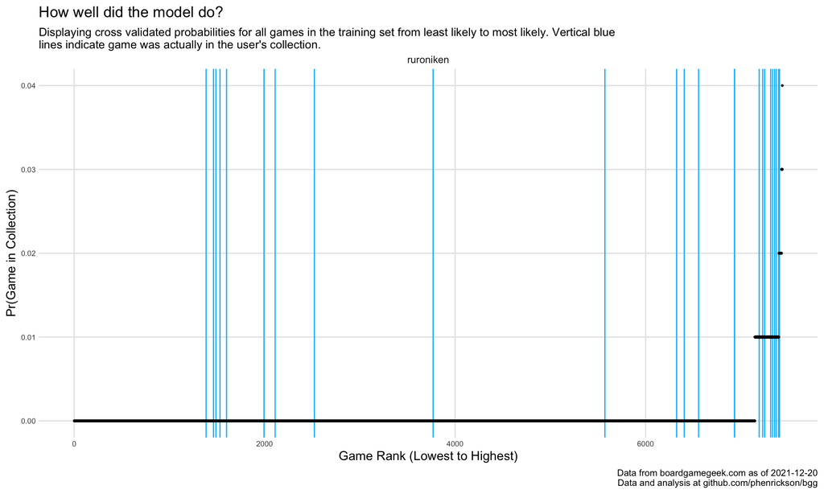

## 3.2 Top Games for **ruroniken** from Training Set

We can display this information in table form, displaying the 100 games with the highest probability of ownership, adding a blue line when the user does own the game.

| username | yearpublished | game_id | name | pred_played | pred_own | actual_played | actual_own |
| --- | --- | --- | --- | --- | --- | --- | --- |
| ruroniken | 2014 | 146886 | La Granja | 0.03 | 0.04 | 0 | 0 |
| ruroniken | 2009 | 26566 | Homesteaders | 0.01 | 0.03 | 0 | 0 |
| ruroniken | 2019 | 284825 | Florenza Dice Game | 0.02 | 0.03 | 0 | 0 |
| ruroniken | 2015 | 180593 | The Bloody Inn | 0.02 | 0.03 | 0 | 0 |
| ruroniken | 2011 | 85800 | Octopus's Garden | 0.02 | 0.03 | 0 | 0 |
| ruroniken | 2017 | 174430 | Gloomhaven | 0.01 | 0.03 | 1 | 0 |
| ruroniken | 2018 | 224517 | Brass: Birmingham | 0.04 | 0.03 | 0 | 0 |
| ruroniken | 2004 | 2651 | Power Grid | 0.02 | 0.03 | 0 | 0 |
| ruroniken | 2019 | 280480 | Crystal Palace | 0.02 | 0.03 | 0 | 0 |
| ruroniken | 1973 | 2995 | Sniper! | 0.01 | 0.02 | 0 | 0 |
| ruroniken | 2018 | 247236 | Duelosaur Island | 0.02 | 0.02 | 0 | 0 |
| ruroniken | 2014 | 163412 | Patchwork | 0.03 | 0.02 | 0 | 0 |
| ruroniken | 2014 | 159675 | Fields of Arle | 0.03 | 0.02 | 0 | 0 |
| ruroniken | 2018 | 244711 | Newton | 0.03 | 0.02 | 0 | 0 |
| ruroniken | 2019 | 281259 | The Isle of Cats | 0.01 | 0.02 | 1 | 1 |
| ruroniken | 2011 | 84419 | Space Empires: 4X | 0.02 | 0.02 | 0 | 0 |
| ruroniken | 2015 | 204184 | Risk: Europe | 0.05 | 0.02 | 0 | 0 |
| ruroniken | 2017 | 193728 | Pendragon: The Fall of Roman Britain | 0.05 | 0.02 | 0 | 0 |
| ruroniken | 2019 | 270971 | Era: Medieval Age | 0.03 | 0.02 | 0 | 0 |
| ruroniken | 2017 | 220308 | Gaia Project | 0.03 | 0.02 | 0 | 0 |
| ruroniken | 2018 | 247763 | Underwater Cities | 0.02 | 0.02 | 0 | 0 |
| ruroniken | 2019 | 251247 | Barrage | 0.03 | 0.02 | 0 | 0 |
| ruroniken | 2019 | 276025 | Maracaibo | 0.05 | 0.02 | 0 | 0 |
| ruroniken | 2015 | 171623 | The Voyages of Marco Polo | 0.02 | 0.02 | 0 | 0 |
| ruroniken | 1933 | 1406 | Monopoly | 0.05 | 0.02 | 0 | 0 |
| ruroniken | 2016 | 205398 | Citadels | 0.00 | 0.02 | 0 | 0 |
| ruroniken | 1995 | 46 | Medici | 0.01 | 0.02 | 0 | 0 |
| ruroniken | 2013 | 147623 | Friese's Landlord | 0.00 | 0.02 | 0 | 0 |
| ruroniken | 2005 | 17133 | Railways of the World | 0.03 | 0.02 | 0 | 0 |
| ruroniken | 2012 | 128780 | Pax Porfiriana | 0.04 | 0.02 | 0 | 0 |

[output cut: 70 more lines]

We can also more formally assess how well the model did in resampling by looking at the area under the receiver operating characteristic. A perfect model would receive a score of 1, while a model that cannot predict the outcome will default to a score of 0.5. The extent to which something is a *good* score depends on the setting, but generally anything in the .8 to .9 range is very good while the .7 to .8 range is perfectly acceptable.

| username | outcome_type | .metric | .estimator | .estimate |
| --- | --- | --- | --- | --- |
| ruroniken | own | roc_auc | binary | 0.792 |
| ruroniken | played | roc_auc | binary | 0.822 |

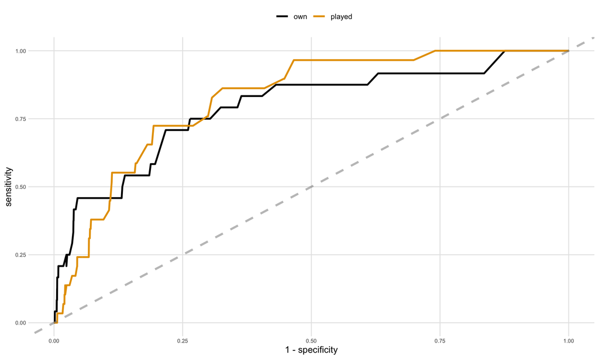

Another way to think about the model performance is to view its lift, or its ability to detect the positive outcomes over that of a null model. High lift indicates the model can much more quickly find all of the positive outcomes (in this case, games owned or played by the user), while a model with no lift is no better than random guessing.

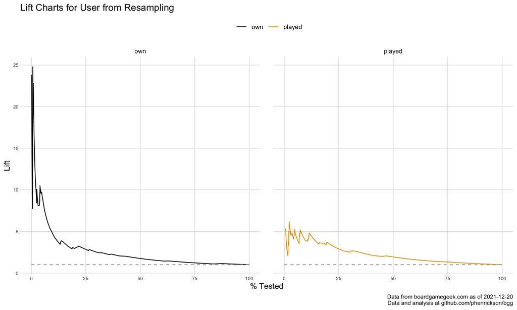

## 3.3 Most and Least Likely Games

What games does the model think ruroniken is **most likely to own** that are **not** in their collection?

| username | yearpublished | game_id | name | pred_own | actual_own |
| --- | --- | --- | --- | --- | --- |
| ruroniken | 2014 | 146886 | La Granja | 0.04 | 0 |
| ruroniken | 2009 | 26566 | Homesteaders | 0.03 | 0 |
| ruroniken | 2019 | 284825 | Florenza Dice Game | 0.03 | 0 |
| ruroniken | 2015 | 180593 | The Bloody Inn | 0.03 | 0 |
| ruroniken | 2011 | 85800 | Octopus's Garden | 0.03 | 0 |

What games does the model think ruroniken is **least likely to own** that **are** in their collection?

| username | yearpublished | game_id | name | pred_own | actual_own |
| --- | --- | --- | --- | --- | --- |
| ruroniken | 2018 | 237182 | Root | 0 | 1 |
| ruroniken | 2012 | 115746 | War of the Ring: Second Edition | 0 | 1 |
| ruroniken | 2019 | 271896 | Star Wars: Outer Rim | 0 | 1 |
| ruroniken | 2012 | 117985 | Star Trek: Catan | 0 | 1 |
| ruroniken | 1977 | 811 | Rummikub | 0 | 1 |

## 3.4 Top Games by Year

Top 25 games most likely to be owned by the user in each year, highlighting in blue the games that the user has owned/played.

| rank | 2011 | 2012 | 2013 | 2014 | 2015 | 2016 | 2017 | 2018 | 2019 |
| --- | --- | --- | --- | --- | --- | --- | --- | --- | --- |
| 1 | Octopus's Garden | Pax Porfiriana | Friese's Landlord | La Granja | The Bloody Inn | Citadels | Gloomhaven | Brass: Birmingham | Florenza Dice Game |
| 2 | Space Empires: 4X | Terra Mystica | Hoplomachus: Rise of Rome | Patchwork | Risk: Europe | The Networks | Pendragon: The Fall of Roman Britain | Duelosaur Island | Crystal Palace |
| 3 | Gears of War: The Board Game | Spartacus: A Game of Blood and Treachery | Cruel Necessity: The English Civil Wars 1640-1653 | Fields of Arle | The Voyages of Marco Polo | Bohemian Villages | Gaia Project | Newton | The Isle of Cats |
| 4 | Santiago de Cuba | Clash of Cultures | Pathfinder Adventure Card Game: Rise of the Runelords – Base Set | Heroes of Normandie | Raptor | Terraforming Mars | Aristeia! | Underwater Cities | Era: Medieval Age |
| 5 | Discworld: Ankh-Morpork | Smash Up | City of Remnants | Five Tribes | Chaosmos | Exceed Fighting System | LYNGK | The Order of Vampire Hunters | Barrage |
| 6 | Mage Knight Board Game | Freedom: The Underground Railroad | The Witches: A Discworld Game | Spyfall | Burgle Bros. | Inis | Triplock | Everdell | Maracaibo |
| 7 | Eclipse | Robinson Crusoe: Adventures on the Cursed Island | Legacy: The Testament of Duke de Crecy | 1944: Race to the Rhine | The Pursuit of Happiness | Days of Ire: Budapest 1956 | Fog of Love | Deck Box Dungeons | Tapestry |
| 8 | A Game of Thrones: The Board Game (Second Edition) | Kill the Overlord | Prosperity | Ultimate Werewolf | Trickerion: Legends of Illusion | Bloc by Bloc: The Insurrection Game | Mythic Battles: Pantheon | Luxor | Nevsky: Teutons and Rus in Collision 1240-1242 |
| 9 | Panic Station | Rex: Final Days of an Empire | Patchistory | Hyperborea | Runebound (Third Edition) | Aventuria: Adventure Card Game | Carthago: Merchants & Guilds | Sonar Family | Hearts and Minds: Vietnam 1965-1975 (Third Edition) |
| 10 | Band of Brothers: Screaming Eagles | Exodus: Proxima Centauri | Eldritch Horror | King of New York | Thunderbirds | Falling Sky: The Gallic Revolt Against Caesar | Plague Inc.: The Board Game | GKR: Heavy Hitters | Unmatched: Robin Hood vs. Bigfoot |
| 11 | A Few Acres of Snow | Zombicide | LEADERS: The Combined Strategy Game | Power Grid Deluxe: Europe/North America | Argonauts | Aeon's End | Stop Thief! | Big Trouble in Little China: The Game | Aeon's End: Legacy |
| 12 | Sekigahara: The Unification of Japan | Keyflower | Impulse | Legendary Encounters: An Alien Deck Building Game | The King Is Dead | Kanagawa | Photosynthesis | Vengeance | Circadians: First Light |
| 13 | Fighting Formations: Grossdeutschland Motorized Infantry Division | Space Cadets | Spyrium | Istanbul | 504 | A Feast for Odin | Rescue Polar Bears: Data & Temperature | Founders of Gloomhaven | Cloudspire |
| 14 | No Retreat! The Russian Front | Descent: Journeys in the Dark (Second Edition) | Concordia | Saint Petersburg (Second Edition) | Through the Ages: A New Story of Civilization | Islebound | Spirit Island | AuZtralia | Middara: Unintentional Malum – Act 1 |
| 15 | Nightfighter | Escape: The Curse of the Temple | Dungeon Command: Blood of Gruumsh | Irish Gauge | Grand Austria Hotel | Mechs vs. Minions | Too Many Bones | Shadows: Amsterdam | Nanty Narking |
| 16 | Space Infantry | Kings of War | Band of Brothers: Ghost Panzer | Tiny Epic Kingdoms | Steampunk Rally | The Oracle of Delphi | Near and Far | Stalingrad: Inferno on the Volga | Minecraft: Builders & Biomes |
| 17 | No Peace Without Spain!: The War of the Spanish Succession 1702-1713 | Mage Wars Arena | BattleLore: Second Edition | Dead of Winter: A Crossroads Game | Alien vs Predator: The Hunt Begins | Crazy Karts | Clans of Caledonia | Pax Emancipation | Last Bastion |
| 18 | FAB: Sicily | Dungeon Command: Sting of Lolth | No Retreat!: The North African Front | Star Wars: Imperial Assault | The King's Armory | The Oregon Trail Card Game | Dinosaur Island | Muse: Awakenings | Living Planet |
| 19 | Revolver | Dungeon Command: Heart of Cormyr | Crusade and Revolution: The Spanish Civil War, 1936-1939 | Fallen | Mission: Red Planet (Second Edition) | Junk Art | The 7th Continent | Renegade | Posthuman Saga |
| 20 | 1955: The War of Espionage | Dungeon Command: Curse of Undeath | Sedition Wars: Battle for Alabaster | Holdfast: Russia 1941-42 | Viticulture Essential Edition | Black Orchestra | Breaking Bad: The Board Game | The Pirate Republic | Tainted Grail: The Fall of Avalon |
| 21 | Test of Fire: Bull Run 1861 | DreadBall: The Futuristic Sports Game | Dungeon Twister: The Card Game | Strife: Legacy of the Eternals | Super Dungeon Explore: Forgotten King | Pandemic: Iberia | Magic Maze | Betrayal Legacy | Clank!: Legacy – Acquisitions Incorporated |
| 22 | Steam Torpedo: First Contact | Kingdom of Heaven: The Crusader States 1097-1291 | Invaders | Star Wars: Empire vs. Rebellion | Tesla vs. Edison: War of Currents | Dawn of the Zeds (Third Edition) | Dragonfire | Nemesis | Marco Polo II: In the Service of the Khan |
| 23 | Yomi | Celles: The Ardennes, December 23-27, 1944 | Risk: Plants vs. Zombies | Fleet Commander: 1 – Ignition | March of the Ants | The Manhattan Project: Energy Empire | Charterstone | Empires of the Void II | On Tour |
| 24 | Laser Chess | Antike Duellum | Metallum | Jäger und Späher | Food Chain Magnate | Dead of Winter: The Long Night | Sub Terra | Franchise | Arena: The Contest |
| 25 | Omen: A Reign of War | Targi | France '40 | Space Hulk (Fourth Edition) | Tiny Epic Galaxies | Scythe | Betrayal at Baldur's Gate | Pandemic: Fall of Rome | Hellenica: Story of Greece |

## 3.5 Interactive Predictions from Resampling

Interactive table for predictions from resampling.

|  | username | yearpublished | rank | game_id | name | pred_played | pred_own | actual_played | actual_own |
| --- | --- | --- | --- | --- | --- | --- | --- | --- | --- |
| 1 | ruroniken | 1900 | 304 | 5546 | Marbles | 0 | 0 | 0 | 0 |
| 2 | ruroniken | 1900 | 307 | 11901 | Tic-Tac-Toe | 0 | 0 | 0 | 0 |
| 3 | ruroniken | 1900 | 354 | 188 | Go | 0 | 0 | 0 | 0 |
| 4 | ruroniken | 1900 | 460 | 171 | Chess | 0 | 0 | 0 | 0 |
| 5 | ruroniken | 1900 | 471 | 2065 | Shogi | 0 | 0 | 0 | 0 |
| 6 | ruroniken | 1900 | 473 | 2393 | Xiangqi | 0 | 0 | 0 | 0 |
| 7 | ruroniken | 1900 | 711 | 26952 | International Checkers | 0 | 0 | 0 | 0 |
| 8 | ruroniken | 1900 | 748 | 1602 | The Royal Game of Ur | 0 | 0 | 0 | 0 |
| 9 | ruroniken | 1900 | 749 | 2083 | Checkers | 0 | 0 | 0 | 0 |
| 10 | ruroniken | 1900 | 757 | 2389 | Othello | 0 | 0 | 0 | 0 |

[output cut: 7426 more lines]

# 4 Validating the Model on 2020

How well did a model trained on a user’s collection through 2019 perform in predicting games for the user from 2020?

| username | outcome_type | yearpublished | .metric | .estimator | .estimate |
| --- | --- | --- | --- | --- | --- |
| ruroniken | own | 2020 | roc_auc | binary | 0.757 |
| ruroniken | played | 2020 | roc_auc | binary | 0.757 |

Table of top 25 games from 2020, highlighting games that the user owns.

| username | yearpublished | game_id | name | pred_own | pred_played | actual_own | actual_played |
| --- | --- | --- | --- | --- | --- | --- | --- |
| ruroniken | 2020 | 256317 | Guild Master | 0.04 | 0.09 | 0 | 0 |
| ruroniken | 2020 | 184267 | On Mars | 0.03 | 0.08 | 0 | 0 |
| ruroniken | 2020 | 246900 | Eclipse: Second Dawn for the Galaxy | 0.03 | 0.04 | 0 | 0 |
| ruroniken | 2020 | 294047 | Superclub | 0.02 | 0.02 | 0 | 0 |
| ruroniken | 2020 | 294788 | Conqueror: Final Conquest | 0.02 | 0.03 | 0 | 0 |
| ruroniken | 2020 | 300322 | Hallertau | 0.02 | 0.03 | 0 | 0 |
| ruroniken | 2020 | 303057 | Pan Am | 0.02 | 0.02 | 0 | 0 |
| ruroniken | 2020 | 308765 | Praga Caput Regni | 0.02 | 0.02 | 0 | 0 |
| ruroniken | 2020 | 310442 | Feierabend | 0.02 | 0.02 | 0 | 0 |
| ruroniken | 2020 | 320819 | Dinner in Paris | 0.02 | 0.02 | 0 | 0 |
| ruroniken | 2020 | 217990 | Stellar Horizons | 0.01 | 0.01 | 0 | 0 |
| ruroniken | 2020 | 236713 | Sea of Plunder | 0.01 | 0.01 | 0 | 0 |
| ruroniken | 2020 | 256589 | Rallyman: GT | 0.01 | 0.01 | 0 | 0 |
| ruroniken | 2020 | 256940 | Krosmaster: Blast | 0.01 | 0.01 | 0 | 0 |
| ruroniken | 2020 | 262274 | D6: Dungeons, Dudes, Dames, Danger, Dice and Dragons! | 0.01 | 0.01 | 0 | 0 |
| ruroniken | 2020 | 282922 | Windward | 0.01 | 0.01 | 0 | 0 |
| ruroniken | 2020 | 284742 | Honey Buzz | 0.01 | 0.01 | 0 | 0 |
| ruroniken | 2020 | 286021 | Free Market: NYC | 0.01 | 0.01 | 0 | 0 |
| ruroniken | 2020 | 288539 | The Jaws of Victory: Battle of Korsun-Cherkassy Pocket – January/February 1944 | 0.01 | 0.01 | 0 | 0 |
| ruroniken | 2020 | 291457 | Gloomhaven: Jaws of the Lion | 0.01 | 0.03 | 1 | 1 |
| ruroniken | 2020 | 292333 | Cowboys II: Cowboys & Indians Edition | 0.01 | 0.04 | 0 | 0 |
| ruroniken | 2020 | 294652 | By Stealth and Sea | 0.01 | 0.01 | 0 | 0 |
| ruroniken | 2020 | 295577 | Dungeon Mayhem: Monster Madness | 0.01 | 0.01 | 0 | 0 |
| ruroniken | 2020 | 295905 | Cosmic Frog | 0.01 | 0.02 | 1 | 1 |
| ruroniken | 2020 | 297030 | Tekhenu: Obelisk of the Sun | 0.01 | 0.01 | 0 | 0 |

# 5 Predicting Upcoming Games (2020 and On) for **ruroniken**

Examine the top games for the test set.

| username | yearpublished | game_id | name | rank | own | played |
| --- | --- | --- | --- | --- | --- | --- |
| ruroniken | 2020 | 256317 | Guild Master | 1 | 0.04 | 0.09 |
| ruroniken | 2020 | 246900 | Eclipse: Second Dawn for the Galaxy | 2 | 0.03 | 0.04 |
| ruroniken | 2020 | 184267 | On Mars | 3 | 0.03 | 0.08 |
| ruroniken | 2020 | 294047 | Superclub | 4 | 0.02 | 0.02 |
| ruroniken | 2020 | 310442 | Feierabend | 5 | 0.02 | 0.02 |
| ruroniken | 2020 | 320819 | Dinner in Paris | 6 | 0.02 | 0.02 |
| ruroniken | 2020 | 303057 | Pan Am | 7 | 0.02 | 0.02 |
| ruroniken | 2020 | 308765 | Praga Caput Regni | 8 | 0.02 | 0.02 |
| ruroniken | 2020 | 294788 | Conqueror: Final Conquest | 9 | 0.02 | 0.03 |
| ruroniken | 2020 | 300322 | Hallertau | 10 | 0.02 | 0.03 |
| ruroniken | 2020 | 236713 | Sea of Plunder | 11 | 0.01 | 0.01 |
| ruroniken | 2020 | 256589 | Rallyman: GT | 12 | 0.01 | 0.01 |
| ruroniken | 2020 | 284742 | Honey Buzz | 13 | 0.01 | 0.01 |
| ruroniken | 2020 | 286021 | Free Market: NYC | 14 | 0.01 | 0.01 |
| ruroniken | 2020 | 288539 | The Jaws of Victory: Battle of Korsun-Cherkassy Pocket – January/February 1944 | 15 | 0.01 | 0.01 |
| ruroniken | 2020 | 294652 | By Stealth and Sea | 16 | 0.01 | 0.01 |
| ruroniken | 2020 | 299252 | Here to Slay | 17 | 0.01 | 0.01 |
| ruroniken | 2020 | 302840 | Carcata | 18 | 0.01 | 0.01 |
| ruroniken | 2020 | 306481 | Tawantinsuyu: The Inca Empire | 19 | 0.01 | 0.01 |
| ruroniken | 2020 | 312965 | Hogs of War: The Miniatures Game | 20 | 0.01 | 0.01 |
| ruroniken | 2020 | 315196 | Dungeons & Dragons: Adventure Begins | 21 | 0.01 | 0.01 |
| ruroniken | 2020 | 306735 | Under Falling Skies | 22 | 0.01 | 0.01 |
| ruroniken | 2020 | 316750 | The Princess Bride Adventure Book Game | 23 | 0.01 | 0.01 |
| ruroniken | 2020 | 326767 | Infinity N4: Core Rules | 24 | 0.01 | 0.01 |
| ruroniken | 2020 | 256940 | Krosmaster: Blast | 25 | 0.01 | 0.01 |
| ruroniken | 2021 | 343905 | Boonlake | 1 | 0.03 | 0.05 |
| ruroniken | 2021 | 310873 | Carnegie | 2 | 0.03 | 0.08 |
| ruroniken | 2021 | 238799 | Messina 1347 | 3 | 0.02 | 0.01 |
| ruroniken | 2021 | 292375 | The Great Wall | 4 | 0.02 | 0.01 |
| ruroniken | 2021 | 320446 | Corduba 27 a.C. | 5 | 0.02 | 0.02 |
| ruroniken | 2021 | 309319 | Apogee | 6 | 0.02 | 0.02 |
| ruroniken | 2021 | 328569 | Mint Bid | 7 | 0.02 | 0.02 |
| ruroniken | 2021 | 295535 | Dark Ages: Heritage of Charlemagne | 8 | 0.02 | 0.02 |
| ruroniken | 2021 | 304985 | Dark Ages: Holy Roman Empire | 9 | 0.02 | 0.02 |
| ruroniken | 2021 | 342942 | Ark Nova | 10 | 0.02 | 0.03 |
| ruroniken | 2021 | 260524 | Beyond Humanity: Colonies | 11 | 0.01 | 0.01 |
| ruroniken | 2021 | 281676 | Galactic Era | 12 | 0.01 | 0.01 |
| ruroniken | 2021 | 291847 | Mantis Falls | 13 | 0.01 | 0.01 |
| ruroniken | 2021 | 299566 | Batman: The Animated Series Adventures – Shadow of the Bat | 14 | 0.01 | 0.01 |
| ruroniken | 2021 | 319792 | Fly-A-Way | 15 | 0.01 | 0.01 |
| ruroniken | 2021 | 336195 | League of Dungeoneers | 16 | 0.01 | 0.01 |
| ruroniken | 2021 | 259962 | Stress Botics | 17 | 0.01 | 0.01 |
| ruroniken | 2021 | 300217 | Merchants of the Dark Road | 18 | 0.01 | 0.02 |
| ruroniken | 2021 | 301366 | Caves of Rwenzori | 19 | 0.01 | 0.01 |
| ruroniken | 2021 | 340909 | Gloomholdin' | 20 | 0.01 | 0.01 |
| ruroniken | 2021 | 285967 | Ankh: Gods of Egypt | 21 | 0.01 | 0.01 |
| ruroniken | 2021 | 295785 | Euthia: Torment of Resurrection | 22 | 0.01 | 0.01 |
| ruroniken | 2021 | 319263 | One Card Dungeon | 23 | 0.01 | 0.02 |
| ruroniken | 2021 | 249277 | Brazil: Imperial | 24 | 0.01 | 0.02 |
| ruroniken | 2021 | 251661 | Oathsworn: Into the Deepwood | 25 | 0.01 | 0.02 |
| ruroniken | 2022 | 330950 | Age of Galaxy | 1 | 0.02 | 0.02 |
| ruroniken | 2022 | 280726 | Legacies | 2 | 0.01 | 0.01 |
| ruroniken | 2022 | 281258 | Sub Terra II: Inferno's Edge | 3 | 0.01 | 0.01 |
| ruroniken | 2022 | 299106 | Fractal: Beyond the Void | 4 | 0.01 | 0.01 |
| ruroniken | 2022 | 304051 | Creature Comforts | 5 | 0.01 | 0.01 |
| ruroniken | 2022 | 311823 | Nova Aetas Renaissance | 6 | 0.01 | 0.01 |
| ruroniken | 2022 | 312959 | Rallyman: DIRT | 7 | 0.01 | 0.01 |
| ruroniken | 2022 | 340325 | Vagrantsong | 8 | 0.01 | 0.01 |
| ruroniken | 2022 | 256680 | Return to Dark Tower | 9 | 0.01 | 0.01 |
| ruroniken | 2022 | 338067 | 6: Siege – The Board Game | 10 | 0.01 | 0.01 |
| ruroniken | 2022 | 283137 | Human Punishment: The Beginning | 11 | 0.01 | 0.01 |
| ruroniken | 2022 | 273814 | Deliverance | 12 | 0.01 | 0.02 |
| ruroniken | 2022 | 317321 | Darkest Dungeon: The Board Game | 13 | 0.01 | 0.02 |
| ruroniken | 2022 | 331106 | The Witcher: Old World | 14 | 0.01 | 0.02 |
| ruroniken | 2022 | 295770 | Frosthaven | 15 | 0.01 | 0.03 |
| ruroniken | 2022 | 317511 | Tindaya | 16 | 0.01 | 0.04 |
| ruroniken | 2022 | 322524 | Bardsung | 17 | 0.01 | 0.03 |
| ruroniken | 2022 | 284189 | Foundations of Rome | 18 | 0.01 | 0.01 |
| ruroniken | 2022 | 295895 | Distilled | 19 | 0.01 | 0.01 |
| ruroniken | 2022 | 155250 | TseuQuesT | 20 | 0.00 | 0.00 |
| ruroniken | 2022 | 286158 | D.E.I.: Divide et Impera | 21 | 0.00 | 0.00 |
| ruroniken | 2022 | 266064 | Trudvang Legends | 22 | 0.00 | 0.00 |
| ruroniken | 2022 | 274056 | HEL: The Last Saga | 23 | 0.00 | 0.00 |
| ruroniken | 2022 | 322354 | DEFCON 1 | 24 | 0.00 | 0.00 |
| ruroniken | 2022 | 253759 | Paint the Roses | 25 | 0.00 | 0.00 |

## 5.1 Interactive Table for Upcoming Games 2020 and On

|  | username | yearpublished | game_id | name | rank | own | played |
| --- | --- | --- | --- | --- | --- | --- | --- |
| 1 | ruroniken | 2020 | 256317 | Guild Master | 1 | 0.04 | 0.09 |
| 2 | ruroniken | 2021 | 343905 | Boonlake | 2 | 0.03 | 0.05 |
| 3 | ruroniken | 2020 | 246900 | Eclipse: Second Dawn for the Galaxy | 3 | 0.03 | 0.04 |
| 4 | ruroniken | 2020 | 184267 | On Mars | 4 | 0.03 | 0.08 |
| 5 | ruroniken | 2021 | 310873 | Carnegie | 5 | 0.03 | 0.08 |
| 6 | ruroniken | 2021 | 238799 | Messina 1347 | 6 | 0.02 | 0.01 |
| 7 | ruroniken | 2021 | 292375 | The Great Wall | 7 | 0.02 | 0.01 |
| 8 | ruroniken | 2020 | 294047 | Superclub | 8 | 0.02 | 0.02 |
| 9 | ruroniken | 2020 | 310442 | Feierabend | 9 | 0.02 | 0.02 |
| 10 | ruroniken | 2020 | 320819 | Dinner in Paris | 10 | 0.02 | 0.02 |

[output cut: 1627 more lines]